# Гипотезы да АБ-тесты: доля, среднее и дисперсия

Филипп

2018-05-24

## Agenda

- Правда и ничего кроме правды
- Множественная проверка гипотез

## Способы проверить гипотезу

> Какие способы проверить гипотезу вы уже знаете?

## Способы проверить гипотезу

> Какие способы проверить гипотезу вы уже знаете?
- Предположить распределение и использовать параметрический критерий
- Бутстрап

## Критерий отношения правдоподобия

**Шаг первый:** оценили модель методом максимального правдоподобия без ограничений и получили $L(\hat \theta_{ML})$

**Шаг второй:** оценили модель, наложив ограничение и получили $L(\hat \theta_{0})$

Оказывается, что

$$LR = 2\cdot(\ln L(\hat \theta_{ML}) - \ln L(\theta_0)) \sim \chi^2_q,$$
где $q$ — число ограничений

## Пример первый

Пусть $X_1, \ldots, X_60 \sim iid \hspace{1mm} Pois(\lambda)$ — количество кино, которое смотрит Женя в неделю. Получилось, что $\sum X_i = 100$. Нужно проверить гипотезу о том, что

$$H_0: \lambda = 2 \\
H_A: \lambda \ne 2$$

$$lnL = \sum x_i \ln \lambda - n \lambda$$
$$\lambda_{ML} = \bar x = \frac{5}{3}$$

## Пример первый

$$LR = 2\cdot(\ln L(\hat \theta_{ML}) - \ln L(\theta_0)) \sim \chi^2_q,$$

```r
lnL <- function(l){
    return(100*log(l) - 60*l)
  }

2*(lnL(5/3) - lnL(2))
qchisq(0.975, df=1)
```

```
## [1] 3.535689
## [1] 5.023886
```

## Пример второй

В [табличке](https://yadi.sk/i/hDxMJ0fw3VSDmu) лежит информация о стоимости квартир в Москве и о основных параметрах этих квартир. Пусть цена на квартиры имеет логарифмически нормальное распределение. Оцените параметры $\mu$ и $\sigma$ методом максимального правдоподобия. Постройте для оценок доверительные интервалы.

```
##   n price totsp livesp kitsp dist metrdist walk brick floor code
## 1 1    81    58     40     6 12.5        7    1     1     1    3
## 2 2    75    44     28     6 13.5        7    1     0     1    6
## 3 3   128    70     42     6 14.5        3    1     1     1    3
## 4 4    95    61     37     6 13.5        7    1     0     1    1
## 5 5   330   104     60    11 10.5        7    0     1     1    3
## 6 6   137    76     50     9 11.0        7    1     1     1    8
```

## Пример второй

```r
x = log(df$price)

lnL <- function(param,data) {
  n <- length(data)
  result <- -n/2*log(2*pi)-n/2*log(param[2]^2)-sum((data-param[1])^2)/(2*param[2]^2)
  return(result)
}

library('maxLik')
res <- maxLik(lnL, start=c(0.1,0.1),data=x)
summary(res)
```

```
## --------------------------------------------
## Maximum Likelihood estimation
## Newton-Raphson maximisation, 16 iterations
## Return code 1: gradient close to zero
## Log-Likelihood: -539.0942
## 2  free parameters
## Estimates:
##      Estimate Std. error t value Pr(> t)
## [1,] 4.791375   0.006978  686.66  <2e-16 ***
## [2,] 0.315159   0.004934   63.87  <2e-16 ***
## ---
## Signif. codes:  0 '***' 0.001 '**' 0.01 '*' 0.05 '.' 0.1 ' ' 1
## --------------------------------------------
```

## Пример второй

```r
#lnL_res <- function(sigma,data) lnL(c(5,sigma),x)
#res_restr <- maxLik(lnL_res, start=0.1,data=x)
#summary(res_restr)
#par_restr <- c(5, res_restr$estimate)

#2*(lnL(par, x) - lnL(par_restr, x))
#qchisq(0.975, df=1)
```

## Критерии максимальной мощности

- В примерах выше мы сравнивали $\frac{L_{ML}}{L_R}$ с единицей
- На основе этого мы делали вывод насколько сильно различаются два правдоподобия и решали что делать с гипотезой
- Сравнивать отношение правдоподобий можно не с единицей, а с какой-то константой $c$
- Лемма Неймана-Пирсона утверждает, что можно подобрать $c$ таким, чтобы у критерий была максимальная мощность (это было на лекции)
- Подробнее смотри в Черновой страницы 86-67

## История про Зомби-лосося

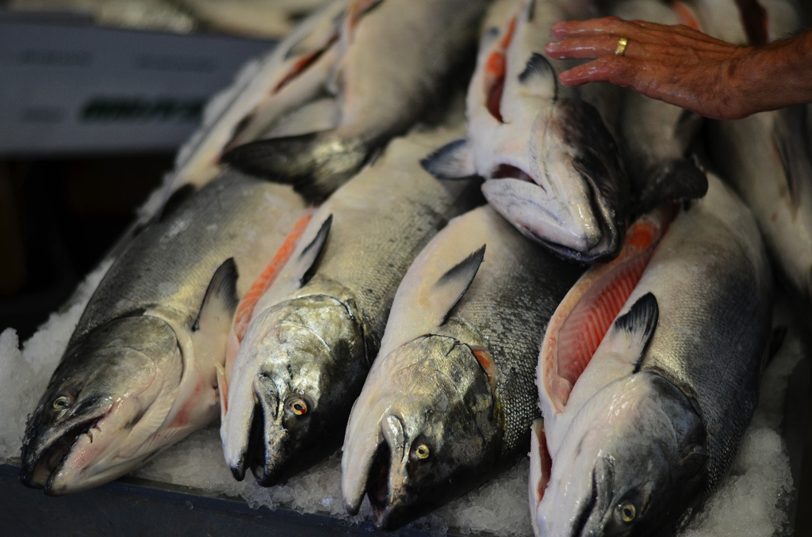

## История про Зомби-лосося

- В 2012 году ряд авторов получил шнобелевскую премию по нейробиологии
- Нужно было протестировать аппарат МРТ, обычно для этого берут шарик с маслом и сканируют его

[figure not shown]

## История про Зомби-лосося

- Скучно, купили мёртвого лосося
- Стали показывать ему фотки людей
- Задача показать, что в голове лосося нет мозговой активности
- Аппарат МРТ возвращает кучу данных. Один объект - воксель. Для исследования активности мозга в целом, надо провести множественное тестирование гипотез относительно каждого вокселя.
- Оказалось, что у лосося есть рекация в мозгу на людей, написали [статью](http://prefrontal.org/files/posters/Bennett-Salmon-2009.pdf)

## Проверка гипотезы

Уровень значимости $P(\text{отвергнуть} H_0 \mid H_0 \text{верна}) = \alpha$

Выборка $X_1, \ldots, X_n \sim iid \hspace{1mm} F_X(x, \theta)$

Статистика $T(X_1, \ldots, X_n)$

Если p-значение $< \alpha$, гипотеза отвергается

## Две гипотезы

- Гипотеза сразу о двух параметрах
- Всё усложняется: можно ошибиться в обеих гипотезах, ошибиться только в первой или только во второй
- Накопление вероятности ошибки первого рода

$$P(\text{ошибочно отвергнуть } H_0 ) = \\ = P(\text{ошибочно отвергнуть хотя бы одну из гипотез}) \le \\
\le P(\text{ошибка в первой}) + P(\text{ошибка во второй}) = \\ = \alpha + \alpha = 2\alpha$$

## Рецепт лечения

- Будем проверять каждую из двух гипотез на уровне значимости $\frac{\alpha}{2}$
- Если гипотез $K$, то каждую проверяем на уровне $\frac{\alpha}{K}$
- Такой подход называется поправкой Бонферрони

## Разрешение парадокса о лососе

- Если ввести поправку Бонферрони, мёртвый лосось остаётся мёртвым
- Реальный вклад в науку, анализ работ по нйробиологии до 2010 года показал, что окло 40% не используют поправку при множественном тестировании гипотез
- После публикации количество статей, где его не используют упало до 10%

## Другие поправки

- Поправку Бонферрони просто применять, но у такой процедуры низкая мощность
- Можно улучшить её, если брать $\alpha_i$ разными

## Нисходящие методы

- Отсортируем полученные p-значения

$$p_{(1)} \le p_{(2)} \le \ldots \le p_{(m)}$$
- Если $p_{(1)} \ge \alpha_1$, не отвергаем все нулевые гипотезы, иначе отвергаем $H_{(1)}$ и продолжаем

- Если $p_{(2)} \ge \alpha_2$, не отвергаем все нулевые гипотезы, иначе отвергаем $H_{(2)}$ и продолжаем
- Делаем так, пока не закончатся гипотезы

## Метод Холма

Если взять уровни значимости

$$\alpha_1 = \frac{\alpha}{m}, \alpha_2 = \frac{\alpha}{m-1}, \ldots, \alpha_i = \frac{\alpha}{m-i+1}, \ldots, \alpha_m = \alpha$$
мы получим **метод холма.**

## На любой ответ найдётся вопрос

- Если $X \sim \chi^2_n$ и $Y \sim \chi^2_{n+1}$, $X$ и $Y$ независимы, тогда $X$ всегда меньше $Y$

## На любой ответ найдётся вопрос

- График плотности случайной величины, имеющей $t$ распределение симметричен относительно нуля

## На любой ответ найдётся вопрос

- Если $X \sim t_n$ тогда $X^2 \sim F_{1,n}$

## На любой ответ найдётся вопрос

- Если гипотеза отвергается при $5\%$ уровне значимости, то она будет отвергаться и при $1\%$ уровне значимости
- Если гипотеза отвергается при $5\%$ уровне значимости, то она будет отвергаться и при $10\%$ уровне значимости

## На любой ответ найдётся вопрос

- У $t$-распределения более толстые хвосты, чем у стандартного нормального. Из-за этого случайная величина, имеющая $t$-распределение более предсказуема, чем случайная величина, имеющая нормальное распределение

## На любой ответ найдётся вопрос

- Если $X \sim N(0,1)$, то $X^2 \sim \chi^2_1$

## На любой ответ найдётся вопрос

- Мощность теста можно рассчитать заранее, до проведения теста.
- Точное P-значение можно расчитать заранее, до проведения теста

## На любой ответ найдётся вопрос

- Мощность больше у того теста, у которого вероятность ошибки первого рода меньше

## На любой ответ найдётся вопрос

- Оценки метода моментов всегда несмещённые
- Оценки метода максимального правдоподобия всегда несмещённые

## На любой ответ найдётся вопрос

- Из несмещённости оценки всегда следует её состоятельность
- Если $Var(\hat \theta) \to 0$, тогда оценка состоятельная

## На любой ответ найдётся вопрос